# Virus - Virushost Species.

A comparison of TR characteristics in viral proteins and the proteins of their host species.

March, 2019

# Housekeeping

```
##          used (Mb) gc trigger (Mb) max used (Mb)
## Ncells 460256 24.6    1001191 53.5   627651 33.6
## Vcells 904759  7.0    8388608 64.0  1752011 13.4
```

# Viral Proteins and their TRs

Label each TR with a TR_identifier.

```r
## Problem: one Protein can have several TRs. To know (later when dataframe in long format) how many TRs a protein has, label them with an identifier.
# nrow(tr_all_sp) # number of TRs
# length(unique(tr_all_sp$ID)) # number of proteins with TRs
tr_all_sp <- tr_all_sp %>%
  mutate(TR_id = row_number())

str(tr_all_sp)
```

```
## 'data.frame':    377134 obs. of  37 variables:
##  $ ID                       : Factor w/ 262720 levels "A0A023PXA5","A0A023PXB0",..: 1 2 3 4 5 6 7 8 9 10 ...
##  $ MSA                      : Factor w/ 297693 levels "---------------------------------------------------------------------------------------------------------------"| __truncated__,..: 22427 285374 103298 103116 215173 145768 236582 153328 102243 160289 ...
##  $ begin                    : int  17 7 8 40 32 91 54 86 79 25 ...
##  $ pvalue                   : num  0.0019 0.0049 0.0001 0.0001 0 ...
##  $ l_effective              : int  9 8 4 4 3 2 4 3 4 3 ...
##  $ n                        : int  2 3 2 2 2 4 2 2 2 2 ...
##  $ n_effective              : num  2 3 2 2 2 4 2 2 2 2 ...
##  $ TRD                      : Factor w/ 4 levels "HHrepID","PFAM",..: 1 1 4 4 4 4 4 4 4 4 ...
##  $ model                    : Factor w/ 1121 levels "cpHMM","None",..: 2 2 2 2 2 2 2 1 2 2 ...
##  $ disordered_overlap       : int  0 0 0 0 2 0 0 2 0 0 ...
##  $ total_repeat_length      : num  18 24 8 8 6 8 8 6 8 6 ...
##  $ center                   : num  25.5 18.5 11.5 43.5 34.5 94.5 57.5 88.5 82.5 27.5 ...
##  $ l_type                   : chr  "small" "small" "small" "small" ...
##  $ fraction_disordered_chars: num  0 0 0 0 0.333 ...
```

[output cut: 23 more lines]

From all Tandem Repeats, select only those which are viral (Superkingdom = Viruses) and have a known Virushost.

```r
# filter all tandem repeat containing proteins from Swissprot which have annotated virushosts
tr_all_sp_virus <- tr_all_sp[!(tr_all_sp$virus_hosts == ""),]
str(tr_all_sp_virus)
```

```
## 'data.frame':    13263 obs. of  37 variables:
##  $ ID                       : Factor w/ 262720 levels "A0A023PXA5","A0A023PXB0",..: 243 243 243 1572 1572 1573 1574 1574 1592 1609 ...
##  $ MSA                      : Factor w/ 297693 levels "---------------------------------------------------------------------------------------------------------------"| __truncated__,..: 158300 281920 266720 291871 164231 261031 256283 101819 51346 50146 ...
##  $ begin                    : int  574 1517 3194 1312 1868 214 202 178 181 2110 ...
##  $ pvalue                   : num  2e-04 2e-04 0e+00 2e-04 2e-04 ...
##  $ l_effective              : int  3 3 3 4 4 4 3 8 4 3 ...
##  $ n                        : int  3 2 2 2 2 2 3 2 2 2 ...
##  $ n_effective              : num  2.67 2 2 2 2 ...
##  $ TRD                      : Factor w/ 4 levels "HHrepID","PFAM",..: 4 4 4 4 4 4 4 1 4 4 ...
##  $ model                    : Factor w/ 1121 levels "cpHMM","None",..: 1 1 1 1 1 2 2 2 2 2 ...
##  $ disordered_overlap       : int  8 0 5 0 0 0 0 0 0 0 ...
##  $ total_repeat_length      : num  8 6 6 8 8 8 7 16 8 6 ...
##  $ center                   : num  578 1520 3196 1316 1872 ...
##  $ l_type                   : chr  "micro" "micro" "micro" "small" ...
##  $ fraction_disordered_chars: num  1 0 0.833 0 0 ...
```

[output cut: 23 more lines]

```r
# no. of viral proteins in Swissprot
length(unique(sp_all$ID[which(sp_all$Superkingdom == "Viruses")]))
```

```
## [1] 16605
```

```r
nrow(sp_all[which(sp_all$Superkingdom == "Viruses"),])
```

```
## [1] 16605
```

```r
# no. of viral proteins in Swissprot containing TRs
length(unique(tr_all_sp$ID[which(tr_all_sp$Superkingdom == "Viruses")]))
```

```
## [1] 7237
```

```r
# no. of TRs found in viral proteins in Swissprot
nrow(tr_all_sp[which(tr_all_sp$Superkingdom == "Viruses"),])
```

```
## [1] 13337
```

```r
# contingency table of all TR sequences found in viral proteins.
tr_all_sp_virus$ID <- factor(tr_all_sp_virus$ID, levels = unique(tr_all_sp_virus$ID)) # drop unused levels
table(table(tr_all_sp_virus$ID))
```

```
##
##    1    2    3    4    5    6    7    8    9   10   11   12   13   14   15
## 4227 1622  667  317  142   83   46   25   23   11   12    7    2    5    1
##   17   18   23   24   32
##    2    2    1    1    1
```

```r
# no. of viral proteins in Swissprot with annotated virus host
length(unique(sp_all$ID[which(sp_all$Superkingdom == "Viruses" & !sp_all$virus_hosts == "" & !is.na(sp_all$virus_hosts))]))
```

```
## [1] 16531
```

```r
# no. of viral proteins in Swissprot containing TRs and annotated virus hosts
length(unique(tr_all_sp_virus$ID))
```

```
## [1] 7197
```

```r
# no. of TRs found in viral proteins and annotated virus hosts
length(tr_all_sp_virus$ID)
```

```
## [1] 13263
```

```r
# % of viral proteins all viral proteins in swissprot
round(
  length(unique(sp_all$ID[which(sp_all$Superkingdom == "Viruses")])) / length(unique(sp_all$ID)), 3)
```

```
## [1] 0.03
```

```r
# % of viral proteins with 1 TR of all viral proteins in swissprot
round(
  length(unique(tr_all_sp$ID[which(tr_all_sp$Superkingdom == "Viruses")])) / length(unique(sp_all$ID[which(sp_all$Superkingdom == "Viruses")])), 3)
```

```
## [1] 0.436
```

```r
# % of viral proteins with >= 4 TR of all viral proteins in swissprot
morethan4 <- subset(data.frame(table(tr_all_sp$ID[which(tr_all_sp$Superkingdom == "Viruses")])), Freq >= 4)
round(
  nrow(morethan4) / length(unique(sp_all$ID[which(sp_all$Superkingdom == "Viruses")])), 3)
```

```
## [1] 0.041
```

Of the 16605 viral proteins in Swissprot KB, 7237 viral proteins contain at least one TR. In total we could detect 13337 TR-regions in viral proteins. (this info is already summarized in the table). We found further that of the 7237 viral proteins with TRs, 4227 have 1 TR, 1622 have 2TRs, 667 have 3TRs. Almost all viral proteins from Swissprot were annotated with the viral host (16531 proteins) and of those, 7197 contain at least one TR. Overall we could find 13263 TR-regions with annotated viral host. Of all curated proteins in Swissprot, 3% come from viruses. From all viral proteins, 43.6% contain at least one TR and 4.1% contain $\geq 4$ TR. NOTE: (200) more viral proteins and ~2000 proteins with TR less detected than julia msc thesis

# Virus host species and their TRs

Viral TRs can be found in multiple species. To get a tidy list, we put each host species in a single row and add two more columns with the Species taxonomic identifier of which the Superkingdom is determined by calling the NCBI Taxonomic Database.

```r
## split the TR with multiple virus-hosts to get single entries for each virus host
tr_all_sp_virus.long <- tr_all_sp_virus %>%
  mutate(virus_hosts = strsplit(as.character(virus_hosts), "; ")) %>%
  unnest(virus_hosts)

## add column with virus_host_superkingdom: found by Species ID
tr_all_sp_virus.long$Species_ID_virushost <- as.numeric(gsub("\\D", "", tr_all_sp_virus.long$virus_hosts)) # extract the TaxID from each virushost and add it as a seperate column
# tr_all_sp_virus.long$Superkingdom_virushost <- simplify2array(
#   mclapply(tr_all_sp_virus.long$Species_ID_virushost, FUN = function(x){
#     ifelse(x %in% sp_all$Species_ID, sp_all$Superkingdom[which(sp_all$Species_ID == x)], NA)},
#     mc.cores = 7))
#NOTE: works, but gives many NAs as it relies on the the species listed in swissprot.

## add column with virus_host_superkingdom: found in NCBI https://www.ncbi.nlm.nih.gov/Taxonomy/TaxIdentifier/tax_identifier.cgi
# write_csv(as.data.frame(tr_all_sp_virus.long$Species_ID_virushost), "/home/matteo/polybox/MSc_ACLS/swissrepeat/data/species_id_virushost2lineage.csv", col_names = FALSE)
#NOTE: Server crashed when manually uploaded.

# different approach with library taxize
# species_ID2Superkingdom <- classification(tr_all_sp_virus.long$Species_ID_virushost, db = "ncbi", callopts=list(http_version = 0L)) # check local_config.R for setting up an API key.
# # Curl trubleshooting (I got http2 error):
# # 1. update curl:
# # install.packages("curl")
# # 2. try this:
# # httr::set_config(httr::config(http_version = 0))
# NOTE: HTTP error 500 or curl error...
#
# get_superkingdom <- function(species_id){
#   return(classification(species_id, db = "ncbi")[[1]][2,1])
# }
#
# tr_all_sp_virus.long$Superkingdom_virushost[1:20] <- simplify2array(
#   mclapply(tr_all_sp_virus.long$Species_ID_virushost[1:20], FUN = get_superkingdom,
#     mc.cores = numcores))

# Different approach with taxonomy file from NCBI Taxonomy database
# manually downloaded NCBI taxonomy categories file:
# read .dmp file which looks like tab separated
taxid2superkingdom <- read.delim("/home/matteo/polybox/MSc_ACLS/swissrepeat/data/categories.dmp", header = FALSE, sep = "\t")
colnames(taxid2superkingdom) <- c("superkingdom", "species_taxid", "taxid") # see readme file in data folder for detailed description
taxid2superkingdom$superkingdom <- as.factor(taxid2superkingdom$superkingdom)

tr_all_sp_virus.long$Superkingdom_virushost <- simplify2array(
  mclapply(tr_all_sp_virus.long$Species_ID_virushost, FUN = function(x){
    ifelse(x %in% taxid2superkingdom$taxid, as.character(taxid2superkingdom$superkingdom[which(taxid2superkingdom$taxid == x)]), NA)},
    mc.cores = 7))

# replace single letters with full names
tr_all_sp_virus.long$Superkingdom_virushost[tr_all_sp_virus.long$Superkingdom_virushost == "E"] <- "Eukaryotic viruses"
tr_all_sp_virus.long$Superkingdom_virushost[tr_all_sp_virus.long$Superkingdom_virushost == "B"] <- "Bacterial viruses"
tr_all_sp_virus.long$Superkingdom_virushost[tr_all_sp_virus.long$Superkingdom_virushost == "A"] <- "archaeal viruses"

# set levels to Species_virushost and Superkingdom_virushost
tr_all_sp_virus.long$Species_ID_virushost <- factor(tr_all_sp_virus.long$Species_ID_virushost, levels = unique(tr_all_sp_virus.long$Species_ID_virushost))
tr_all_sp_virus.long$Superkingdom_virushost <- factor(tr_all_sp_virus.long$Superkingdom_virushost, levels = unique(tr_all_sp_virus.long$Superkingdom_virushost))
tr_all_sp_virus.long$TR_id <- factor(tr_all_sp_virus.long$TR_id, levels = unique(tr_all_sp_virus.long$TR_id))
```

## Summary statistics about the virushost superkingdom:

```r
# no. of different virushosts
length(unique(tr_all_sp_virus.long$Species_ID_virushost))
```

```
## [1] 771
```

```r
# # how often each virus host superkingdom appears in TR
table(tr_all_sp_virus.long$Superkingdom_virushost)
```

```
##
## Eukaryotic viruses  Bacterial viruses   archaeal viruses
##              19512                671                209
```

```r
# % of superkingdom
eukaryotic_virushost_fraction <- round(table(tr_all_sp_virus.long$Superkingdom_virushost)[[1]]/nrow(tr_all_sp_virus.long),3)
eukaryotic_virushost_fraction
```

```
## [1] 0.814
```

```r
bacterial_virushost_fraction <- round(table(tr_all_sp_virus.long$Superkingdom_virushost)[[2]]/nrow(tr_all_sp_virus.long),3)
bacterial_virushost_fraction
```

```
## [1] 0.028
```

```r
archaeal_virushost_fraction <- round(table(tr_all_sp_virus.long$Superkingdom_virushost)[[3]]/nrow(tr_all_sp_virus.long),3)
archaeal_virushost_fraction
```

```
## [1] 0.009
```

```r
str(tr_all_sp_virus.long)
```

```
## 'data.frame':    23971 obs. of  39 variables:
##  $ ID                       : Factor w/ 7197 levels "A0AUJ5","A0MD28",..: 1 1 1 2 2 3 4 4 5 6 ...
##  $ MSA                      : Factor w/ 297693 levels "---------------------------------------------------------------------------------------------------------------"| __truncated__,..: 158300 281920 266720 291871 164231 261031 256283 101819 51346 50146 ...
##  $ begin                    : int  574 1517 3194 1312 1868 214 202 178 181 2110 ...
##  $ pvalue                   : num  2e-04 2e-04 0e+00 2e-04 2e-04 ...
##  $ l_effective              : int  3 3 3 4 4 4 3 8 4 3 ...
##  $ n                        : int  3 2 2 2 2 2 3 2 2 2 ...
##  $ n_effective              : num  2.67 2 2 2 2 ...
##  $ TRD                      : Factor w/ 4 levels "HHrepID","PFAM",..: 4 4 4 4 4 4 4 1 4 4 ...
##  $ model                    : Factor w/ 1121 levels "cpHMM","None",..: 1 1 1 1 1 2 2 2 2 2 ...
##  $ disordered_overlap       : int  8 0 5 0 0 0 0 0 0 0 ...
##  $ total_repeat_length      : num  8 6 6 8 8 8 7 16 8 6 ...
##  $ center                   : num  578 1520 3196 1316 1872 ...
##  $ l_type                   : chr  "micro" "micro" "micro" "small" ...
##  $ fraction_disordered_chars: num  1 0 0.833 0 0 ...
```

[output cut: 25 more lines]

```r
unique(tr_all_sp_virus.long$Superkingdom_virushost)
```

```
## [1] Eukaryotic viruses Bacterial viruses  <NA>
## [4] archaeal viruses
## Levels: Eukaryotic viruses Bacterial viruses archaeal viruses
```

771 different virus host species were found in viral Proteins containing TRs (and are annotated in Swissprot). 81.4% of viral TRs have a eukaryotic host organism but only 2.8% have a bacterial host organism and 0.9% have archaeal hosts.

CONCERN: biased data: more intensively investigated species (model organisms and humans) appear more often.

```r
x <- data.frame(table(tr_all_sp_virus.long$Species_ID_virushost)) # get counts of each virus host species tax id's
x <- x[order(x$Freq, decreasing = TRUE),] # list the species_id which appears the most at top
x <- x[1:100,] # look only at a subsection. Not to overload NCBI servers with requests ;-)

get_taxname <- function(species_id){
  evo_tree <- classification(as.character(species_id), db = "ncbi", callopts=list(http_version = 0L))[[1]]
  return(evo_tree[nrow(evo_tree),1])
}

x$taxname_virushost[1:20] <- simplify2array(
  lapply(x$Var1[1:20], FUN = get_taxname)) # mclapply doesn't work (too many requests ^^)
x
```

```
##       Var1 Freq        taxname_virushost
## 10    9606 5187             Homo sapiens
## 2     9823 1328               Sus scrofa
## 53    5757 1277   Acanthamoeba polyphaga
## 14    8782  626                     Aves
## 11    9913  617               Bos taurus
## 64    9796  545           Equus caballus
## 71    6937  510             Ornithodoros
## 72   85517  418 Phacochoerus aethiopicus
## 73   41426  418   Phacochoerus africanus
## 74  273792  418   Potamochoerus larvatus
## 35   10090  354             Mus musculus
## 30    9598  305          Pan troglodytes
## 3      562  290         Escherichia coli
## 165   9031  270            Gallus gallus
```

[output cut: 86 more lines]

The initial concern doesn’t seem to be true. As wild swines are no common model organisms neither is Acanthamoeba polyphaga.

Look at the virushost species from all proteins listed in swissprot. Especially to those, with no TRs.

```r
## split the TR with multiple virus-hosts to get single entries for each virus host
sp_all.long <- sp_all %>%
  mutate(virus_hosts = strsplit(as.character(virus_hosts), "; ")) %>%
  unnest(virus_hosts)

## add column with virus_host_superkingdom: found by Species ID
sp_all.long$Species_ID_virushost <- as.numeric(gsub("\\D", "", sp_all.long$virus_hosts)) # extract the TaxID from each virushost and add it as a seperate column

# Different approach with taxonomy file from NCBI Taxonomy database
# manually downloaded NCBI taxonomy categories file:
# read .dmp file which looks like tab separated
taxid2superkingdom <- read.delim("/home/matteo/polybox/MSc_ACLS/swissrepeat/data/categories.dmp", header = FALSE, sep = "\t")
colnames(taxid2superkingdom) <- c("superkingdom", "species_taxid", "taxid") # see readme file in data folder for detailed description
taxid2superkingdom$superkingdom <- as.factor(taxid2superkingdom$superkingdom)

sp_all.long$Superkingdom_virushost <- simplify2array(
  mclapply(sp_all.long$Species_ID_virushost, FUN = function(x){
    ifelse(x %in% taxid2superkingdom$taxid, as.character(taxid2superkingdom$superkingdom[which(taxid2superkingdom$taxid == x)]), NA)},
    mc.cores = 7))

# replace single letters with full names
sp_all.long$Superkingdom_virushost[sp_all.long$Superkingdom_virushost == "E"] <- "Eukaryotic viruses"
sp_all.long$Superkingdom_virushost[sp_all.long$Superkingdom_virushost == "B"] <- "Bacterial viruses"
sp_all.long$Superkingdom_virushost[sp_all.long$Superkingdom_virushost == "A"] <- "archaeal viruses"

# set levels to Species_virushost and Superkingdom_virushost
sp_all.long$Species_ID_virushost <- factor(sp_all.long$Species_ID_virushost, levels = unique(sp_all.long$Species_ID_virushost))
sp_all.long$Superkingdom_virushost <- factor(sp_all.long$Superkingdom_virushost, levels = unique(sp_all.long$Superkingdom_virushost))

## Initialize vectors for each host SK
SK <- data.frame(Var1 = c("Eukaryotic_viruses", "Bacterial_viruses", "archaeal_viruses", "NAs"),
                 Freq = c(0,0,0,0))

# no. of virushosts per protein with Eukaryotic superkingdom
table(table(sp_all.long$ID[which(sp_all.long$Superkingdom_virushost == "Eukaryotic viruses")]))
```

```
##
##    1    2    3    4    5    6    7    8    9   10   11   12   13   15   17
## 8808 1438  436 1030  606  254  154   69   27    7   11    2    9    1    3
##   21   23
##   10   39
```

```r
# no. of virushosts per protein with Eukaryotic superkingdom and TR
table(table(sp_all.long$ID[which(sp_all.long$Superkingdom_virushost == "Eukaryotic viruses" & sp_all.long$has_tr == TRUE)]))
```

```
##
##    1    2    3    4    5    6    7    8    9   10   11   12   13   15   21
## 4233  653  203  446  238  107   66   29   10    4    5    1    2    1    2
##   23
##   15
```

```r
# no. of virushosts per protein with Eukaryotic superkingdom without TR
table(table(sp_all.long$ID[which(sp_all.long$Superkingdom_virushost == "Eukaryotic viruses" & sp_all.long$has_tr == FALSE)]))
```

```
##
##    1    2    3    4    5    6    7    8    9   10   11   12   13   17   21
## 4575  785  233  584  368  147   88   40   17    3    6    1    7    3    8
##   23
##   24
```

# Combine Virus Protein information with Host-species Protein information

### Problematic:

One protein can have several TRs.

```r
select(tr_all_sp, TR_id, ID)[10:15,]
```

```
##    TR_id         ID
## 10    10 A0A023PXI0
## 11    11 A0A023PXI8
## 12    12 A0A023PXK2
## 13    13 A0A023PXK2
## 14    14 A0A023PXK7
## 15    15 A0A023PXK7
```

one Protein can have several origins (Species_ID), hence appear in different Superkingdoms.

```r
select(tr_all_sp, TR_id, ID, Species_ID)
```

```
##       TR_id         ID Species_ID
## 1         1 A0A023PXA5       4932
## 2         2 A0A023PXB0       4932
## 3         3 A0A023PXC2       4932
## 4         4 A0A023PXD9       4932
## 5         5 A0A023PXE5       4932
## 6         6 A0A023PXE8       4932
## 7         7 A0A023PXF2       4932
## 8         8 A0A023PXF5       4932
## 9         9 A0A023PXG7       4932
## 10       10 A0A023PXI0       4932
## 11       11 A0A023PXI8       4932
## 12       12 A0A023PXK2       4932
## 13       13 A0A023PXK2       4932
## 14       14 A0A023PXK7       4932
```

[output cut: 33320 more lines]

one viral Protein can have multiple hosts and one viral TR can appear in multiple hosts (TR_id 8961 appear in host 4072, 4097, …)

```r
select(tr_all_sp_virus.long, TR_id, ID, Species_ID, Species_ID_virushost)[8:19,]
```

```
##    TR_id     ID Species_ID Species_ID_virushost
## 8   1839 A0MD32      28344                 9823
## 9   1879 A0MZE1         NA                  562
## 10  1900 A0PJ24         NA                42520
## 11  8961 A1XIP9     370833                 4072
## 12  8961 A1XIP9     370833                 4097
## 13  8961 A1XIP9     370833                 4081
## 14  8961 A1XIP9     370833                 4111
## 15  8961 A1XIP9     370833                 4113
## 16  8962 A1XIP9     370833                 4072
## 17  8962 A1XIP9     370833                 4097
## 18  8962 A1XIP9     370833                 4081
## 19  8962 A1XIP9     370833                 4111
```

### Attempt 1: Put all the information in one table

#### Count TR by host Superkingdoms

```r
## Initialize vectors for each host SK
SK <- data.frame(Var1 = c("Eukaryotic_viruses", "Bacterial_viruses", "archaeal_viruses", "NAs"),
Freq = c(0,0,0,0))

## Determine for each viral TR it's host SK
for ( i in tr_all_sp_virus.long$ID){
  # SK <- table(tr_all_sp_virus.long$Superkingdom_virushost[1])
  # SK <- SK + table(tr_all_sp_virus.long$Superkingdom_virushost[which(tr_all_sp_virus.long$TR_id == i)])
  # print(table(tr_all_sp_virus.long$Superkingdom_virushost[which(tr_all_sp_virus.long$TR_id == i)]))
  temp <- as.data.frame(table(tr_all_sp_virus.long$Superkingdom_virushost[which(tr_all_sp_virus.long$ID == i)]))
  if (nrow(temp) == 0){
    SK$Freq[which(SK$Var1 == "NAs")]  <- SK$Freq[which(SK$Var1 == "NAs")] + 1
  } else {
    for (j in 1:nrow(temp)){
      # print(j)}}
      if (temp[j,1] == "Eukaryotic viruses"){
        SK$Freq[which(SK$Var1 == "Eukaryotic_viruses")]  <- SK$Freq[j] + temp$Freq[j]
      } else if(temp[j,1] == "Bacterial viruses"){
        SK$Freq[which(SK$Var1 == "Bacterial_viruses")]  <- SK$Freq[j] + temp$Freq[j]
      } else if (temp[j,1] == "archaeal viruses"){
        SK$Freq[which(SK$Var1 == "archaeal_viruses")]  <- SK$Freq[j] + temp$Freq[j]
      }
    }
  }
}

SK
```

```
##                 Var1   Freq
## 1 Eukaryotic_viruses 186274
## 2  Bacterial_viruses   3399
## 3   archaeal_viruses    885
## 4                NAs      0
```

### Attempt 2: Extract the information of each table seperately and but it toghether afterwards. Not all-in-one table

To get the correlation between the TR content of viral proteins and the TR content of their host organisms. TODO: Find out if more important to get the length of the TRs (how many units they have) or the TR content per protein?

all proteins (w/ and w/o) which have a viral host annotated:

```r
nrow(sp_all[which(sp_all$virus_hosts != ""),])
```

```
## [1] 16531
```

all protein which have TRs and an annotated host:

```r
nrow(tr_all_sp[which(tr_all_sp$virus_hosts != ""),])
```

```
## [1] 13263
```

# why not cake diagram: http://static1.squarespace.com/static/56713bf4dc5cb41142f28d1f/5671e8bf816924fc22651410/5671eb2e816924fc22651bc9/1450306350612/devourThePie3.gif?format=original

#### Look up table

for connecting virushost species which have proteins in swissprot with TRs with other tables by either TR_id for information retrieval per TR or Protein_id for information retrieval per Protein or Species_id for information about either TRs or Proteins per species and analogous for superkingdoms.

```r
virushostspecies <- data.frame(TR_ID = tr_all_sp_virus.long$TR_id,
                               Protein_ID = tr_all_sp_virus.long$ID,
                               Species_ID_virushost = tr_all_sp_virus.long$Species_ID_virushost,
                               Superkingdom_virushost = tr_all_sp_virus.long$Superkingdom_virushost)
```

```r
#### Virushost information
# with >0 TRs
df_archaea_virushost <- as.data.frame(table(
  table(tr_all_sp$ID[which(tr_all_sp$Species_ID %in% virushostspecies$Species_ID_virushost &
                             tr_all_sp$Superkingdom == "Archaea")]) # make frequency table of all TRs coming from species, which are virushosts and Archaea
))
# with 0 TRs
df_archaea_virushost[1,2] <- length(sp_all$ID[which(sp_all$Species_ID %in% virushostspecies$Species_ID_virushost &
                                                      sp_all$ID %!in% tr_all_sp$ID &
                                                      sp_all$Superkingdom == "Archaea")]) # count all proteins coming from species which are virushost, have no TRs and are Achaea
# sum all nTR > 4 and add to nTR = 4
colnames(df_archaea_virushost)<- c("nTR", "Freq")
for (i in df_archaea_virushost$nTR){
  if (i >4){
    df_archaea_virushost$Freq[5] <- df_archaea_virushost$Freq[5] + df_archaea_virushost$Freq[which(df_archaea_virushost$nTR == i)]
  }
}
df_archaea_virushost <- df_archaea_virushost[1:5,]
# calculate fraction of nTR
df_archaea_virushost$fraction_nTR <- simplify2array(lapply(df_archaea_virushost$Freq, FUN = function(x){round(as.numeric(x)/sum(df_archaea_virushost$Freq), 3)}))
df_archaea_virushost$Superkingdom <- rep("Archaeaic Virushost", nrow(df_archaea_virushost))

#### Regular information
## get all proteins with archaeal origin:
# with >0 TRs
df_archaea <- as.data.frame(table(
  table(tr_all_sp$ID[which(tr_all_sp$Superkingdom == "Archaea")])
))
# with 0 TRs
df_archaea[1,2] <- length(sp_all$ID[which(sp_all$ID %!in% tr_all_sp$ID & sp_all$Superkingdom == "Archaea")])
# sum all nTR > 4 and add to nTR = 4
colnames(df_archaea)<- c("nTR", "Freq")
for (i in df_archaea$nTR){
  if (i >4){
    df_archaea$Freq[5] <- df_archaea$Freq[5] + df_archaea$Freq[which(df_archaea$nTR == i)]
  }
}
df_archaea <- df_archaea[1:5,]
# calculate fraction of nTR
df_archaea$fraction_nTR <- simplify2array(lapply(df_archaea$Freq, FUN = function(x){round(as.numeric(x)/sum(df_archaea$Freq), 3)}))
df_archaea$Superkingdom <- rep("Archaea", nrow(df_archaea))

#### Put toghether Regular info and Virushost info:
df_archaea <- rbind(df_archaea, df_archaea_virushost)
# # test dataframe:
# df_archaea <- data.frame(Superkingdom = c(rep("Archaea", 5), rep("Archaeal Virus", 5)),
#                          fraction_nTR = c(rep(c(0.71,0.23,0.04,0.01,0.001), 2)),
#                          nTR = c(rep(as.character(seq(0,4,1)))))
df_archaea
```

```
##    nTR  Freq fraction_nTR        Superkingdom
## 1    0 12950        0.669             Archaea
## 2    1  4814        0.249             Archaea
## 3    2  1134        0.059             Archaea
## 4    3   323        0.017             Archaea
## 5    4   147        0.008             Archaea
## 6    0  1058        0.681 Archaeaic Virushost
## 7    1   409        0.263 Archaeaic Virushost
## 8    2    54        0.035 Archaeaic Virushost
## 9    3    24        0.015 Archaeaic Virushost
## 10   4     8        0.005 Archaeaic Virushost
```

```r
str(df_archaea)
```

```
## 'data.frame':    10 obs. of  4 variables:
##  $ nTR         : Factor w/ 12 levels "0","1","2","3",..: 1 2 3 4 5 1 2 3 4 5
##  $ Freq        : int  12950 4814 1134 323 147 1058 409 54 24 8
##  $ fraction_nTR: num  0.669 0.249 0.059 0.017 0.008 0.681 0.263 0.035 0.015 0.005
##  $ Superkingdom: chr  "Archaea" "Archaea" "Archaea" "Archaea" ...
```

```r
#### Plots
if (DOBARPLOT_STACK){
  p <- ggplot(data=df_archaea, aes(x=factor(1), y=fraction_nTR, fill=nTR)) +
    geom_bar(stat="identity", position = "fill")+
    facet_grid(~Superkingdom)+
    # geom_text(aes(y=fraction_nTR, label=nTR), vjust=1.6,
    #           color="white", size=3.5)+
    # geom_label_repel(aes(label = nTR), size=4, show.legend = F, nudge_x = 1,
    #                  segment.size = .5, direction = 'x')+
    scale_fill_brewer(palette="Dark2")+
    ggtitle("Archaea")+
    labs(x="", y="Fraction", fill= "TR count")+
    theme_minimal()
  p <- beautifier(p)+
    theme(
      axis.title.x = element_blank(),
      panel.border = element_blank(),
      panel.grid.minor = element_blank(),
      panel.grid.major.x = element_blank(),
      axis.ticks = element_blank(),
      axis.text.x.bottom = element_blank(),
      plot.title=element_text(size=14, face="bold")
    )
  p
  if (save == TRUE) {
    ggsave(paste0(pathImages, "virus_virushost_archaea_bar", figureFormat), width=12, height=8, dpi = 300)}
} else if (DOPIECHART) {
  p <- ggplot(data=df_archaea, aes(x=factor(1), y=fraction_nTR, fill=nTR)) +
    geom_bar(stat="identity", position = "fill")+
    coord_polar("y") +
    facet_grid(~Superkingdom)+
    # geom_text(aes(y=fraction_nTR, label=nTR), vjust=1.6,
    #           color="white", size=3.5)+
    scale_fill_brewer(palette="Dark2")+
    # ggtitle("Archaea")+
    labs(fill= "TR count")+
    theme_minimal()
  p <- beautifier(p)+
    theme(
      axis.title.x = element_blank(),
      axis.title.y = element_blank(),
      panel.border = element_blank(),
      panel.grid=element_blank(),
      axis.ticks = element_blank(),
      axis.text = element_blank(),
      strip.text = element_text(size=14, face="bold")
      # plot.title=element_text(size=14, face="bold")
    )+
    geom_label_repel(aes(label = paste0(fraction_nTR*100,"%")), size=4, show.legend = F, nudge_x = 1,
                     segment.size = .5, direction = 'x')
  p
  if (save == TRUE) {
    ggsave(paste0(pathImages, "virus_virushost_archaea_pie", figureFormat), width=12, height=8, dpi = 300)}
} else if (DOBARPLOT) {
  p <- ggplot(data=df_archaea, aes(x=df_archaea$nTR, y=df_archaea$fraction_nTR, fill=df_archaea$nTR)) +
    geom_bar(stat="identity")+
    facet_grid(~Superkingdom)+
    # geom_text(aes(y = labpos, label=paste0(fraction_nTR*100,"%")), vjust=1.6,
    #           color="white", size=3.5)+
    # geom_label_repel(aes(label = nTR), size=4, show.legend = F, nudge_x = 1,
    #                  segment.size = .5, direction = 'x')+
    # geom_text(data = ann_text, label=paste0(as.numeric(as.character(ann_text$fraction_nTR))*100,"%"))+
    scale_fill_brewer(palette="Dark2")+
    ggtitle("Archaea")+
    # labs(y="Fraction", x= "TR count", fill = "TR count")+
    labs(y="Fraction", x= "TR count", fill = "TR count")+
    theme_minimal()
  p <- beautifier(p)+
    theme(
      axis.title.x = element_blank(),
      panel.border = element_blank(),
      panel.grid.minor = element_blank(),
      panel.grid.major.x = element_blank(),
      axis.ticks = element_blank(),
      axis.text.x.bottom = element_blank(),
      # axis.text.x.bottom = element_text(angle = 0),
      plot.title=element_text(size=14, face="bold")
    )
  p
  if (save == TRUE) {
    ggsave(paste0(pathImages, "virus_virushost_archaea_bar2", figureFormat), width=12, height=8, dpi = 300)}
}
```

```r
#### Virushost information
# with >0 TRs
df_bacteria_virushost <- as.data.frame(table(
  table(tr_all_sp$ID[which(tr_all_sp$Species_ID %in% virushostspecies$Species_ID_virushost &
                             tr_all_sp$Superkingdom == "Bacteria")]) # make frequency table of all TRs coming from species, which are virushosts and Archaea
))
# with 0 TRs
df_bacteria_virushost[1,2] <- length(sp_all$ID[which(sp_all$Species_ID %in% virushostspecies$Species_ID_virushost &
                                                       sp_all$ID %!in% tr_all_sp$ID &
                                                       sp_all$Superkingdom == "Bacteria")]) # count all proteins coming from species which are virushost, have no TRs and are Achaea
# sum all nTR > 4 and add to nTR = 4
colnames(df_bacteria_virushost)<- c("nTR", "Freq")
for (i in df_bacteria_virushost$nTR){
  if (i >4){
    df_bacteria_virushost$Freq[5] <- df_bacteria_virushost$Freq[5] + df_bacteria_virushost$Freq[which(df_bacteria_virushost$nTR == i)]
  }
}
df_bacteria_virushost <- df_bacteria_virushost[1:5,]
# calculate fraction of nTR
df_bacteria_virushost$fraction_nTR <- simplify2array(lapply(df_bacteria_virushost$Freq, FUN = function(x){round(as.numeric(x)/sum(df_bacteria_virushost$Freq), 3)}))
df_bacteria_virushost$Superkingdom <- rep("Bacterial Virushost", nrow(df_bacteria_virushost))

#### Regular information
## get all proteins with bacterial origin:
# with >0 TRs
df_bacteria <- as.data.frame(table(
  table(tr_all_sp$ID[which(tr_all_sp$Superkingdom == "Bacteria")])
))
# with 0 TRs
df_bacteria[1,2] <- length(sp_all$ID[which(sp_all$ID %!in% tr_all_sp$ID & sp_all$Superkingdom == "Bacteria")])
# sum all nTR > 4 and add to nTR = 4
colnames(df_bacteria)<- c("nTR", "Freq")
for (i in df_bacteria$nTR){
  if (i >4){
    df_bacteria$Freq[5] <- df_bacteria$Freq[5] + df_bacteria$Freq[which(df_bacteria$nTR == i)]
  }
}
df_bacteria <- df_bacteria[1:5,]
# calculate fraction of nTR
df_bacteria$fraction_nTR <- simplify2array(lapply(df_bacteria$Freq, FUN = function(x){round(as.numeric(x)/sum(df_bacteria$Freq), 3)}))
df_bacteria$Superkingdom <- rep("Bacteria", nrow(df_bacteria))

#### Put toghether Regular info and Virushost info:
df_bacteria <- rbind(df_bacteria, df_bacteria_virushost)
df_bacteria
```

```
##    nTR   Freq fraction_nTR        Superkingdom
## 1    0 228485        0.688            Bacteria
## 2    1  76055        0.229            Bacteria
## 3    2  19782        0.060            Bacteria
## 4    3   5429        0.016            Bacteria
## 5    4   2496        0.008            Bacteria
## 6    0  43418        0.703 Bacterial Virushost
## 7    1  13478        0.218 Bacterial Virushost
## 8    2   3524        0.057 Bacterial Virushost
## 9    3    968        0.016 Bacterial Virushost
## 10   4    398        0.006 Bacterial Virushost
```

```r
str(df_bacteria)
```

```
## 'data.frame':    10 obs. of  4 variables:
##  $ nTR         : Factor w/ 36 levels "0","1","2","3",..: 1 2 3 4 5 1 2 3 4 5
##  $ Freq        : int  228485 76055 19782 5429 2496 43418 13478 3524 968 398
##  $ fraction_nTR: num  0.688 0.229 0.06 0.016 0.008 0.703 0.218 0.057 0.016 0.006
##  $ Superkingdom: chr  "Bacteria" "Bacteria" "Bacteria" "Bacteria" ...
```

```r
#### Plots
if (DOBARPLOT_STACK){
  p <- ggplot(data=df_bacteria, aes(x=factor(1), y=fraction_nTR, fill=nTR)) +
    geom_bar(stat="identity", position = "fill")+
    facet_grid(~Superkingdom)+
    # geom_text(aes(y=fraction_nTR, label=nTR), vjust=1.6,
    #           color="white", size=3.5)+
    # geom_label_repel(aes(label = nTR), size=4, show.legend = F, nudge_x = 1,
    #                  segment.size = .5, direction = 'x')+
    scale_fill_brewer(palette="Dark2")+
    ggtitle("Bacteria")+
    labs(x="", y="Fraction", fill= "TR count")+
    theme_minimal()
  p <- beautifier(p)+
    theme(
      axis.title.x = element_blank(),
      panel.border = element_blank(),
      panel.grid.minor = element_blank(),
      panel.grid.major.x = element_blank(),
      axis.ticks = element_blank(),
      axis.text.x.bottom = element_blank(),
      plot.title=element_text(size=14, face="bold")
    )
  p
  if (save == TRUE) {
    ggsave(paste0(pathImages, "virus_virushost_bacteria_bar", figureFormat), width=12, height=8, dpi = 300)}
} else if (DOPIECHART) { # piechart
  p <- ggplot(data=df_bacteria, aes(x=factor(1), y=fraction_nTR, fill=nTR)) +
    geom_bar(stat="identity", position = "fill")+
    coord_polar("y") +
    facet_grid(~Superkingdom)+
    # geom_text(aes(y=fraction_nTR, label=nTR), vjust=1.6,
    #           color="white", size=3.5)+
    scale_fill_brewer(palette="Dark2")+
    # ggtitle("Bacteria")+
    labs(fill= "TR count")+
    theme_minimal()
  p <- beautifier(p)+
    theme(
      axis.title.x = element_blank(),
      axis.title.y = element_blank(),
      panel.border = element_blank(),
      panel.grid=element_blank(),
      axis.ticks = element_blank(),
      axis.text = element_blank(),
      strip.text = element_text(size=14, face="bold")
      # plot.title=element_text(size=14, face="bold")
    )+
    geom_label_repel(aes(label = paste0(fraction_nTR*100,"%")), size=4, show.legend = F, nudge_x = 1,
                     segment.size = .5, direction = 'x')
  p
  if (save == TRUE) {
    ggsave(paste0(pathImages, "virus_virushost_bacteria_pie", figureFormat), width=12, height=8, dpi = 300)}
} else if (DOBARPLOT) {
  p <- ggplot(data=df_bacteria, aes(x=df_bacteria$nTR, y=df_bacteria$fraction_nTR, fill=df_bacteria$nTR)) +
    geom_bar(stat="identity")+
    facet_grid(~Superkingdom)+
    # geom_text(aes(y = labpos, label=paste0(fraction_nTR*100,"%")), vjust=1.6,
    #           color="white", size=3.5)+
    # geom_label_repel(aes(label = nTR), size=4, show.legend = F, nudge_x = 1,
    #                  segment.size = .5, direction = 'x')+
    # geom_text(data = ann_text, label=paste0(as.numeric(as.character(ann_text$fraction_nTR))*100,"%"))+
    scale_fill_brewer(palette="Dark2")+
    ggtitle("Bacteria")+
    # labs(y="Fraction", x= "TR count", fill = "TR count")+
    labs(y="Fraction", x= "TR count", fill = "TR count")+
    theme_minimal()
  p <- beautifier(p)+
    theme(
      axis.title.x = element_blank(),
      panel.border = element_blank(),
      panel.grid.minor = element_blank(),
      panel.grid.major.x = element_blank(),
      axis.ticks = element_blank(),
      axis.text.x.bottom = element_blank(),
      # axis.text.x.bottom = element_text(angle = 0),
      plot.title=element_text(size=14, face="bold")
    )
  p
  if (save == TRUE) {
    ggsave(paste0(pathImages, "virus_virushost_bacteria_bar2", figureFormat), width=12, height=8, dpi = 300)}
}
```

```r
#### Virushost information
# with >0 TRs
df_eukaryota_virushost <- as.data.frame(table(
  table(tr_all_sp$ID[which(tr_all_sp$Species_ID %in% virushostspecies$Species_ID_virushost &
                             tr_all_sp$Superkingdom == "Eukaryota")])
))
# make frequency table of all TRs coming fromk eukaryotic virushost species.

# with 0 TRs
df_eukaryota_virushost[1,2] <- length(sp_all$ID[which(sp_all$Species_ID %in% virushostspecies$Species_ID_virushost &
                                                        sp_all$ID %!in% tr_all_sp$ID &
                                                        sp_all$Superkingdom == "Eukaryota")]) # count all proteins coming from species which are virushost, have no TRs and are Achaea
# sum all nTR > 4 and add to nTR = 4
colnames(df_eukaryota_virushost)<- c("nTR", "Freq")
for (i in df_eukaryota_virushost$nTR){
  if (i >4){
    df_eukaryota_virushost$Freq[5] <- df_eukaryota_virushost$Freq[5] + df_eukaryota_virushost$Freq[which(df_eukaryota_virushost$nTR == i)]
  }
}
df_eukaryota_virushost <- df_eukaryota_virushost[1:5,]
# calculate fraction of nTR
df_eukaryota_virushost$fraction_nTR <- simplify2array(lapply(df_eukaryota_virushost$Freq, FUN = function(x){round(as.numeric(x)/sum(df_eukaryota_virushost$Freq), 3)}))
df_eukaryota_virushost$Superkingdom <- rep("Eukaryotic Virushost", nrow(df_eukaryota_virushost))

#### Regular information
## get all proteins with archaeal origin:
# with >0 TRs
df_eukaryota <- as.data.frame(table(
  table(tr_all_sp$ID[which(tr_all_sp$Superkingdom == "Eukaryota")])
))
# with 0 TRs
df_eukaryota[1,2] <- length(sp_all$ID[which(sp_all$ID %!in% tr_all_sp$ID & sp_all$Superkingdom == "Eukaryota")])
# sum all nTR > 4 and add to nTR = 4
colnames(df_eukaryota)<- c("nTR", "Freq")
for (i in df_eukaryota$nTR){
  if (i >4){
    df_eukaryota$Freq[5] <- df_eukaryota$Freq[5] + df_eukaryota$Freq[which(df_eukaryota$nTR == i)]
  }
}
df_eukaryota <- df_eukaryota[1:5,]
# calculate fraction of nTR
df_eukaryota$fraction_nTR <- simplify2array(lapply(df_eukaryota$Freq, FUN = function(x){round(as.numeric(x)/sum(df_eukaryota$Freq), 3)}))
df_eukaryota$Superkingdom <- rep("Eukaryota", nrow(df_eukaryota))

#### Put toghether Regular info and Virushost info:
df_eukaryota <- rbind(df_eukaryota, df_eukaryota_virushost)

#### Add column for correct labelling
df_eukaryota <- df_eukaryota %>%
  group_by(Superkingdom) %>%
  mutate(labpos = cumsum(fraction_nTR)- fraction_nTR/2)

df_eukaryota
```

```
## # A tibble: 10 x 5
## # Groups:   Superkingdom [2]
##    nTR    Freq fraction_nTR Superkingdom         labpos
##    <fct> <int>        <dbl> <chr>                 <dbl>
##  1 0     89342        0.496 Eukaryota             0.248
##  2 1     47498        0.264 Eukaryota             0.628
##  3 2     21179        0.118 Eukaryota             0.819
##  4 3     10023        0.056 Eukaryota             0.906
##  5 4     12132        0.067 Eukaryota             0.968
##  6 0      6116        0.464 Eukaryotic Virushost  0.232
##  7 1      3673        0.279 Eukaryotic Virushost  0.604
##  8 2      1769        0.134 Eukaryotic Virushost  0.81
##  9 3       829        0.063 Eukaryotic Virushost  0.909
## 10 4       799        0.061 Eukaryotic Virushost  0.971
```

```r
str(df_eukaryota)
```

```
## Classes 'grouped_df', 'tbl_df', 'tbl' and 'data.frame':  10 obs. of  5 variables:
##  $ nTR         : Factor w/ 59 levels "0","1","2","3",..: 1 2 3 4 5 1 2 3 4 5
##  $ Freq        : int  89342 47498 21179 10023 12132 6116 3673 1769 829 799
##  $ fraction_nTR: num  0.496 0.264 0.118 0.056 0.067 0.464 0.279 0.134 0.063 0.061
##  $ Superkingdom: chr  "Eukaryota" "Eukaryota" "Eukaryota" "Eukaryota" ...
##  $ labpos      : num  0.248 0.628 0.819 0.906 0.968 ...
##  - attr(*, "groups")=Classes 'tbl_df', 'tbl' and 'data.frame':   2 obs. of  2 variables:
##   ..$ Superkingdom: chr  "Eukaryota" "Eukaryotic Virushost"
##   ..$ .rows       :List of 2
##   .. ..$ : int  1 2 3 4 5
##   .. ..$ : int  6 7 8 9 10
##   ..- attr(*, ".drop")= logi TRUE
```

```r
#### Plots
if (DOBARPLOT_STACK){
  p <- ggplot(data=df_eukaryota, aes(x=factor(1), y=fraction_nTR, fill=nTR)) +
    geom_bar(stat="identity", position = "fill")+
    facet_grid(~Superkingdom)+
    # geom_text(aes(y=fraction_nTR, label=nTR), vjust=1.6,
    #           color="white", size=3.5)+
    # geom_label_repel(aes(label = nTR), size=4, show.legend = F, nudge_x = 1,
    #                  segment.size = .5, direction = 'x')+
    scale_fill_brewer(palette="Dark2")+
    ggtitle("Eukaryota")+
    labs(x="", y="Fraction", fill= "TR count")+
    theme_minimal()
  p <- beautifier(p)+
    theme(
      axis.title.x = element_blank(),
      panel.border = element_blank(),
      panel.grid.minor = element_blank(),
      panel.grid.major.x = element_blank(),
      axis.ticks = element_blank(),
      axis.text.x.bottom = element_blank(),
      plot.title=element_text(size=14, face="bold")
    )
  p
  if (save == TRUE) {
    ggsave(paste0(pathImages, "virus_virushost_eukaryota_bar", figureFormat), width=12, height=8, dpi = 300)}
} else if (DOPIECHART) { # piechart
  p <- ggplot(data=df_eukaryota, aes(x=factor(1), y=fraction_nTR, fill=nTR)) + # TODO: fix labeling according to: https://stackoverflow.com/questions/24803460/r-ggplot2-add-labels-on-facet-pie-chart
    geom_bar(stat="identity", position = "fill")+
    coord_polar("y") +
    facet_grid(~Superkingdom)+
    # geom_text(aes(y=fraction_nTR, label=nTR), vjust=1.6,
    #           color="white", size=3.5)+
    scale_fill_brewer(palette="Dark2")+
    # ggtitle("Eukaryota")+
    labs(fill= "TR count")+
    theme_minimal()
  p <- beautifier(p)+
    theme(
      axis.title.x = element_blank(),
      axis.title.y = element_blank(),
      panel.border = element_blank(),
      panel.grid=element_blank(),
      axis.ticks = element_blank(),
      axis.text = element_blank(),
      strip.text = element_text(size=14, face="bold")
      # plot.title=element_text(size=14, face="bold")
    )+
    geom_label_repel(aes(label = paste0(fraction_nTR*100,"%")), size=4, show.legend = F, nudge_x = 1,
                     segment.size = .5, direction = 'x')
  # geom_text(aes(y=fraction_nTR, label=nTR), vjust=1.6,
  #           color="white", size=3.5)
  p
  if (save == TRUE) {
    ggsave(paste0(pathImages, "virus_virushost_eukaryota_pie", figureFormat), width=12, height=8, dpi = 300)}
} else if (DOBARPLOT) {
  p <- ggplot(data=df_eukaryota, aes(x=df_eukaryota$nTR, y=df_eukaryota$fraction_nTR, fill=df_eukaryota$nTR)) +
    geom_bar(stat="identity")+
    facet_grid(~Superkingdom)+
    # geom_text(aes(y = labpos, label=paste0(fraction_nTR*100,"%")), vjust=1.6,
    #           color="white", size=3.5)+
    # geom_label_repel(aes(label = nTR), size=4, show.legend = F, nudge_x = 1,
    #                  segment.size = .5, direction = 'x')+
    # geom_text(data = ann_text, label=paste0(as.numeric(as.character(ann_text$fraction_nTR))*100,"%"))+
    scale_fill_brewer(palette="Dark2")+
    ggtitle("Eukaryota")+
    # labs(y="Fraction", x= "TR count", fill = "TR count")+
    labs(y="Fraction", x= "TR count", fill = "TR count")+
    theme_minimal()
  p <- beautifier(p)+
    theme(
      axis.title.x = element_blank(),
      panel.border = element_blank(),
      panel.grid.minor = element_blank(),
      panel.grid.major.x = element_blank(),
      axis.ticks = element_blank(),
      axis.text.x.bottom = element_blank(),
      # axis.text.x.bottom = element_text(angle = 0),
      plot.title=element_text(size=14, face="bold")
    )
  p
  if (save == TRUE) {
    ggsave(paste0(pathImages, "virus_virushost_eukaryota_bar2", figureFormat), width=12, height=8, dpi = 300)}
}
```

same as above, but with the logic from extracting species level information (as i.e. for humans) Why slightly different results? -> With the approach of looking up the information about the superkingdom by tr_id (below), we find higher numbers for 0 TRs but less for >0TRs. Probably due to missing results in `sp_all$Superkingdom` which comes from 2015 swissprot entries and the `virushostspecies_sp$Superkingdom_virushost` is from 2019 ncbi taxonomy database which is expected to be more up to date with more entries

```r
# virushost species which have trs in swissprot
virushostspecies_tr <- data.frame(TR_ID = tr_all_sp_virus.long$TR_id,
                               Protein_ID = tr_all_sp_virus.long$ID,
                               Species_ID_virushost = tr_all_sp_virus.long$Species_ID_virushost,
                               Superkingdom_virushost = tr_all_sp_virus.long$Superkingdom_virushost)

#### Virushost information
# with >0 TRs
df_eukaryota_virushost <- as.data.frame(table(
  table(tr_all_sp$ID[which(tr_all_sp$TR_id %in% virushostspecies_tr$TR_ID[which(virushostspecies_tr$Superkingdom_virushost == "Eukaryotic viruses")])])))
# make frequency table of all TRs coming fromk eukaryotic virushost species.

# with 0 TRs
# virushost species which have proteins in swissprot
virushostspecies_sp <- data.frame(Protein_ID = sp_all.long$ID,
                                  Species_ID_virushost = sp_all.long$Species_ID_virushost,
                                  Superkingdom_virushost = sp_all.long$Superkingdom_virushost)

df_eukaryota_virushost[1,2] <- length(sp_all$ID[which(sp_all$ID %in% as.character(virushostspecies_sp$Protein_ID[which(virushostspecies_sp$Superkingdom_virushost == "Eukaryotic viruses")]) &
                                                        sp_all$ID %!in% tr_all_sp$ID)]) # Take all viral proteins which are from a human host species. From those, select
# sum all nTR > 4 and add to nTR = 4
colnames(df_eukaryota_virushost)<- c("nTR", "Freq")
for (i in df_eukaryota_virushost$nTR){
  if (i >4){
    df_eukaryota_virushost$Freq[5] <- df_eukaryota_virushost$Freq[5] + df_eukaryota_virushost$Freq[which(df_eukaryota_virushost$nTR == i)]
  }
}
df_eukaryota_virushost <- df_eukaryota_virushost[1:5,]
# calculate fraction of nTR
df_eukaryota_virushost$fraction_nTR <- simplify2array(lapply(df_eukaryota_virushost$Freq, FUN = function(x){round(as.numeric(x)/sum(df_eukaryota_virushost$Freq), 3)}))
df_eukaryota_virushost$Superkingdom <- rep("Eukaryotic Virushost", nrow(df_eukaryota_virushost))

#### Regular information
## get all proteins with archaeal origin:
# with >0 TRs
df_eukaryota <- as.data.frame(table(
  table(tr_all_sp$ID[which(tr_all_sp$Superkingdom == "Eukaryota")])
))
# with 0 TRs
df_eukaryota[1,2] <- length(sp_all$ID[which(sp_all$ID %!in% tr_all_sp$ID &
                                              sp_all$Superkingdom == "Eukaryota")])
# sum all nTR > 4 and add to nTR = 4
colnames(df_eukaryota)<- c("nTR", "Freq")
for (i in df_eukaryota$nTR){
  if (i >4){
    df_eukaryota$Freq[5] <- df_eukaryota$Freq[5] + df_eukaryota$Freq[which(df_eukaryota$nTR == i)]
  }
}
df_eukaryota <- df_eukaryota[1:5,]
# calculate fraction of nTR
df_eukaryota$fraction_nTR <- simplify2array(lapply(df_eukaryota$Freq, FUN = function(x){round(as.numeric(x)/sum(df_eukaryota$Freq), 3)}))
df_eukaryota$Superkingdom <- rep("Eukaryota", nrow(df_eukaryota))

#### Put toghether Regular info and Virushost info:
df_eukaryota <- rbind(df_eukaryota, df_eukaryota_virushost)

#### Add column for correct labelling
df_eukaryota <- df_eukaryota %>%
  group_by(Superkingdom) %>%
  # mutate(labpos = cumsum(fraction_nTR)- fraction_nTR/2)
  # mutate(labpos = fraction_nTR *(2*pi)/2)
  mutate(labpos = cumsum(fraction_nTR))

df_eukaryota
```

```
## # A tibble: 10 x 5
## # Groups:   Superkingdom [2]
##    nTR    Freq fraction_nTR Superkingdom         labpos
##    <fct> <int>        <dbl> <chr>                 <dbl>
##  1 0     89342        0.496 Eukaryota             0.496
##  2 1     47498        0.264 Eukaryota             0.76
##  3 2     21179        0.118 Eukaryota             0.878
##  4 3     10023        0.056 Eukaryota             0.934
##  5 4     12132        0.067 Eukaryota             1.00
##  6 0      6889        0.536 Eukaryotic Virushost  0.536
##  7 1      3428        0.266 Eukaryotic Virushost  0.802
##  8 2      1407        0.109 Eukaryotic Virushost  0.911
##  9 3       576        0.045 Eukaryotic Virushost  0.956
## 10 4       564        0.044 Eukaryotic Virushost  1
```

```r
str(df_eukaryota)
```

```
## Classes 'grouped_df', 'tbl_df', 'tbl' and 'data.frame':  10 obs. of  5 variables:
##  $ nTR         : Factor w/ 59 levels "0","1","2","3",..: 1 2 3 4 5 1 2 3 4 5
##  $ Freq        : int  89342 47498 21179 10023 12132 6889 3428 1407 576 564
##  $ fraction_nTR: num  0.496 0.264 0.118 0.056 0.067 0.536 0.266 0.109 0.045 0.044
##  $ Superkingdom: chr  "Eukaryota" "Eukaryota" "Eukaryota" "Eukaryota" ...
##  $ labpos      : num  0.496 0.76 0.878 0.934 1.001 ...
##  - attr(*, "groups")=Classes 'tbl_df', 'tbl' and 'data.frame':   2 obs. of  2 variables:
##   ..$ Superkingdom: chr  "Eukaryota" "Eukaryotic Virushost"
##   ..$ .rows       :List of 2
##   .. ..$ : int  1 2 3 4 5
##   .. ..$ : int  6 7 8 9 10
##   ..- attr(*, ".drop")= logi TRUE
```

```r
# annotation data-frame
# ann_text <- data.frame(fraction_nTR = factor(as.character( c((df_eukaryota$fraction_nTR[1:5]), (df_eukaryota$fraction_nTR[6:10])))),
#                        lab = as.character( c((df_eukaryota$fraction_nTR[1:5]), (df_eukaryota$fraction_nTR[6:10]))),
#                        Superkingdom = df_eukaryota$Superkingdom)

#### Plots
if (DOBARPLOT_STACK){
  p <- ggplot(data=df_eukaryota, aes(x=factor(1), y=df_eukaryota$fraction_nTR, fill=df_eukaryota$nTR)) +
    geom_bar(stat="identity", position = "fill")+
    facet_grid(~Superkingdom)+
    # geom_text(aes(y = labpos, label=paste0(fraction_nTR*100,"%")), vjust=1.6,
    #           color="white", size=3.5)+
    # geom_label_repel(aes(label = nTR), size=4, show.legend = F, nudge_x = 1,
    #                  segment.size = .5, direction = 'x')+
    # geom_text(data = ann_text, label=paste0(as.numeric(as.character(ann_text$fraction_nTR))*100,"%"))+
    scale_fill_brewer(palette="Dark2")+
    ggtitle("Eukaryota")+
    labs(x="", y="Fraction", fill= "TR count")+
    theme_minimal()
  p <- beautifier(p)+
    theme(
      axis.title.x = element_blank(),
      panel.border = element_blank(),
      panel.grid.minor = element_blank(),
      panel.grid.major.x = element_blank(),
      axis.ticks = element_blank(),
      axis.text.x.bottom = element_blank(),
      plot.title=element_text(size=14, face="bold")
    )
  p
  if (save == TRUE) {
    ggsave(paste0(pathImages, "virus_virushost_eukaryota2_bar", figureFormat), width=12, height=8, dpi = 300)}
} else if (DOPIECHART) { # piechart
  p <- ggplot(data=df_eukaryota, aes(x=factor(1), y=fraction_nTR, fill=nTR)) + # TODO: fix labeling according to: https://stackoverflow.com/questions/24803460/r-ggplot2-add-labels-on-facet-pie-chart
    geom_bar(stat="identity", position = "fill")+
    coord_polar("y", start = 0, direction = -1) +
    facet_grid(~Superkingdom)+
    # geom_text(aes(y=fraction_nTR, label=nTR), vjust=1.6,
    #           color="white", size=3.5)+
    scale_fill_brewer(palette="Dark2")+
    # ggtitle("Eukaryota")+
    labs(fill= "TR count")+
    theme_minimal()
  p <- beautifier(p)+
    theme(
      axis.title.x = element_blank(),
      axis.title.y = element_blank(),
      panel.border = element_blank(),
      panel.grid=element_blank(),
      axis.ticks = element_blank(),
      axis.text = element_blank(),
      strip.text = element_text(size=14, face="bold")
      # plot.title=element_text(size=14, face="bold")
    )+
    # geom_label_repel(aes(label = paste0(fraction_nTR*100,"%")), size=4, show.legend = F, nudge_x = 1,
    #                  segment.size = .5, direction = 'x')
    geom_text(aes(y=labpos, label=paste0(fraction_nTR*100,"%")), vjust=1.6,
              color="white", size=3.5)
  p
  if (save == TRUE) {
    ggsave(paste0(pathImages, "virus_virushost_eukaryota2_pie", figureFormat), width=12, height=8, dpi = 300)}
} else if (DOBARPLOT) {
  p <- ggplot(data=df_eukaryota, aes(x=df_eukaryota$nTR, y=df_eukaryota$fraction_nTR, fill=df_eukaryota$nTR)) +
    geom_bar(stat="identity")+
    facet_grid(~Superkingdom)+
    # geom_text(aes(y = labpos, label=paste0(fraction_nTR*100,"%")), vjust=1.6,
    #           color="white", size=3.5)+
    # geom_label_repel(aes(label = nTR), size=4, show.legend = F, nudge_x = 1,
    #                  segment.size = .5, direction = 'x')+
    # geom_text(data = ann_text, label=paste0(as.numeric(as.character(ann_text$fraction_nTR))*100,"%"))+
    scale_fill_brewer(palette="Dark2")+
    ggtitle("Eukaryota2")+
    # labs(y="Fraction", x= "TR count", fill = "TR count")+
    labs(y="Fraction", x= "TR count", fill = "TR count")+
    theme_minimal()
  p <- beautifier(p)+
    theme(
      axis.title.x = element_blank(),
      panel.border = element_blank(),
      panel.grid.minor = element_blank(),
      panel.grid.major.x = element_blank(),
      axis.ticks = element_blank(),
      axis.text.x.bottom = element_blank(),
      # axis.text.x.bottom = element_text(angle = 0),
      plot.title=element_text(size=14, face="bold")
    )
  p
  if (save == TRUE) {
    ggsave(paste0(pathImages, "virus_virushost_eukaryota2_bar2", figureFormat), width=12, height=8, dpi = 300)}
}
```

there are many missing Species_ID i.e. the one from homo sapiens. For the ones, where we have a Species name, we can fill it in with the data from ncbi dowloaded above.

```r
# x <- sp_all[which(is.na(sp_all$Species_ID) & !is.na(sp_all$Species)), c(9,10)] # filter all proteins which have a missing species_id but do have a species name.
# species2species_id <- data.frame(Species_ID = seq(1, length(unique(x$Species))),
#                                  Species = seq(1, length(unique(x$Species))))
# species2species_id$Species <- unique(x$Species) # take all unique species names
#
# get_species_id <- function(species_name){
#   evo_tree <- try(classification(as.character(species_name), db = "ncbi", callopts=list(http_version = 0L))[[1]])
#   if (class(evo_tree) == "try-error") {
#     return(NA)
#   } else {
#       return(evo_tree[nrow(evo_tree),ncol(evo_tree)])
#   }
# }
#
# species2species_id$Species_ID[1:2] <- simplify2array(
#   lapply(species2species_id$Species[1:2], FUN = get_species_id)) # mclapply doesn't work (too many requests ^^)
# species2species_id
```

Let’s query then by species name

```r
#### Virushost information
# virushost species which have trs in swissprot
virushostspecies_tr <- data.frame(TR_ID = tr_all_sp_virus.long$TR_id,
                                  Protein_ID = tr_all_sp_virus.long$ID,
                                  Species_ID_virushost = tr_all_sp_virus.long$Species_ID_virushost,
                                  Superkingdom_virushost = tr_all_sp_virus.long$Superkingdom_virushost)

# with >0 TRs
df_human_virushost <- as.data.frame(table(
  table(tr_all_sp$ID[which(tr_all_sp$TR_id %in% virushostspecies_tr$TR_ID[which(virushostspecies_tr$Species_ID_virushost ==9606)])]) # make frequency table of all TRs coming from species, which are virushosts and Archaea
))
# with 0 TRs
# virushost species which have proteins in swissprot
virushostspecies_sp <- data.frame(Protein_ID = sp_all.long$ID,
                                  Species_ID_virushost = sp_all.long$Species_ID_virushost,
                                  Superkingdom_virushost = sp_all.long$Superkingdom_virushost)

df_human_virushost[1,2] <- length(sp_all$ID[which(sp_all$ID %in% as.character(virushostspecies_sp$Protein_ID[which(virushostspecies_sp$Species_ID_virushost ==9606)]) &
                                                    sp_all$ID %!in% tr_all_sp$ID)]) # Take all viral proteins which are from a human host species. From those, select
# sum all nTR > 4 and add to nTR = 4
colnames(df_human_virushost)<- c("nTR", "Freq")
for (i in df_human_virushost$nTR){
  if (i >4){
    df_human_virushost$Freq[5] <- df_human_virushost$Freq[5] + df_human_virushost$Freq[which(df_human_virushost$nTR == i)]
  }
}
df_human_virushost <- df_human_virushost[1:5,]
# calculate fraction of nTR
df_human_virushost$fraction_nTR <- simplify2array(lapply(df_human_virushost$Freq, FUN = function(x){round(as.numeric(x)/sum(df_human_virushost$Freq), 3)}))
df_human_virushost$Superkingdom <- rep("Human Virushost", nrow(df_human_virushost))

#### Regular information

## get all proteins with archaeal origin:
# with >0 TRs
df_human <- as.data.frame(table(
  table(tr_all_sp$ID[which(tr_all_sp$Species == "Homo sapiens (Human)")])
))
# with 0 TRs
df_human[1,2] <- length(sp_all$ID[which(sp_all$ID %!in% tr_all_sp$ID &
                                          sp_all$Species == "Homo sapiens (Human)")])
# sum all nTR > 4 and add to nTR = 4
colnames(df_human)<- c("nTR", "Freq")
for (i in df_human$nTR){
  if (i >4){
    df_human$Freq[5] <- df_human$Freq[5] + df_human$Freq[which(df_human$nTR == i)]
  }
}
df_human <- df_human[1:5,]
# calculate fraction of nTR
df_human$fraction_nTR <- simplify2array(lapply(df_human$Freq, FUN = function(x){round(as.numeric(x)/sum(df_human$Freq), 3)}))
df_human$Superkingdom <- rep("Human", nrow(df_human))

#### Put toghether Regular info and Virushost info:
df_human <- rbind(df_human, df_human_virushost)

#### Add column for correct labelling
df_human <- df_human %>%
  group_by(Superkingdom) %>%
  # mutate(labpos = cumsum(fraction_nTR)- fraction_nTR/2)
  # mutate(labpos = fraction_nTR *(2*pi)/2)
  mutate(labpos = cumsum(fraction_nTR))
# # test dataframe:
# df_human <- data.frame(Superkingdom = c(rep("Archaea", 5), rep("Archaeal Virus", 5)),
#                          fraction_nTR = c(rep(c(0.71,0.23,0.04,0.01,0.001), 2)),
#                          nTR = c(rep(as.character(seq(0,4,1)))))
df_human
```

```
## # A tibble: 10 x 5
## # Groups:   Superkingdom [2]
##    nTR    Freq fraction_nTR Superkingdom    labpos
##    <fct> <int>        <dbl> <chr>            <dbl>
##  1 0      7465        0.374 Human            0.374
##  2 1      5517        0.277 Human            0.651
##  3 2      3067        0.154 Human            0.805
##  4 3      1647        0.083 Human            0.888
##  5 4      2242        0.112 Human            1
##  6 0      3067        0.523 Human Virushost  0.523
##  7 1      1604        0.273 Human Virushost  0.796
##  8 2       669        0.114 Human Virushost  0.91
##  9 3       258        0.044 Human Virushost  0.954
## 10 4       268        0.046 Human Virushost  1
```

```r
str(df_human)
```

```
## Classes 'grouped_df', 'tbl_df', 'tbl' and 'data.frame':  10 obs. of  5 variables:
##  $ nTR         : Factor w/ 43 levels "0","1","2","3",..: 1 2 3 4 5 1 2 3 4 5
##  $ Freq        : int  7465 5517 3067 1647 2242 3067 1604 669 258 268
##  $ fraction_nTR: num  0.374 0.277 0.154 0.083 0.112 0.523 0.273 0.114 0.044 0.046
##  $ Superkingdom: chr  "Human" "Human" "Human" "Human" ...
##  $ labpos      : num  0.374 0.651 0.805 0.888 1 0.523 0.796 0.91 0.954 1
##  - attr(*, "groups")=Classes 'tbl_df', 'tbl' and 'data.frame':   2 obs. of  2 variables:
##   ..$ Superkingdom: chr  "Human" "Human Virushost"
##   ..$ .rows       :List of 2
##   .. ..$ : int  1 2 3 4 5
##   .. ..$ : int  6 7 8 9 10
##   ..- attr(*, ".drop")= logi TRUE
```

```r
# annotation data-frame
# ann_text <- data.frame(fraction_nTR = factor(as.character( c((df_human$fraction_nTR[1:5]), (df_human$fraction_nTR[6:10])))),
#                        lab = as.character( c((df_human$fraction_nTR[1:5]), (df_human$fraction_nTR[6:10]))),
#                        Superkingdom = df_human$Superkingdom)

#### Plots
if (DOBARPLOT_STACK){
  p <- ggplot(data=df_human, aes(x=factor(1), y=df_human$fraction_nTR, fill=df_human$nTR)) +
    geom_bar(stat="identity", position = "fill")+
    facet_grid(~Superkingdom)+
    # geom_text(aes(y = labpos, label=paste0(fraction_nTR*100,"%")), vjust=1.6,
    #           color="white", size=3.5)+
    # geom_label_repel(aes(label = nTR), size=4, show.legend = F, nudge_x = 1,
    #                  segment.size = .5, direction = 'x')+
    # geom_text(data = ann_text, label=paste0(as.numeric(as.character(ann_text$fraction_nTR))*100,"%"))+
    scale_fill_brewer(palette="Dark2")+
    ggtitle("Homo sapiens")+
    labs(x="", y="Fraction", fill= "TR count")+
    theme_minimal()
  p <- beautifier(p)+
    theme(
      axis.title.x = element_blank(),
      panel.border = element_blank(),
      panel.grid.minor = element_blank(),
      panel.grid.major.x = element_blank(),
      axis.ticks = element_blank(),
      axis.text.x.bottom = element_blank(),
      plot.title=element_text(size=14, face="bold")
    )
  p
  if (save == TRUE) {
    ggsave(paste0(pathImages, "virus_virushost_human_bar", figureFormat), width=12, height=8, dpi = 300)}
} else if (DOPIECHART) { # piechart
  p <- ggplot(data=df_human, aes(x=factor(1), y=fraction_nTR, fill=nTR)) + # TODO: fix labeling according to: https://stackoverflow.com/questions/24803460/r-ggplot2-add-labels-on-facet-pie-chart
    geom_bar(stat="identity", position = "fill")+
    coord_polar("y", start = 0, direction = -1) +
    facet_grid(~Superkingdom)+
    # geom_text(aes(y=fraction_nTR, label=nTR), vjust=1.6,
    #           color="white", size=3.5)+
    scale_fill_brewer(palette="Dark2")+
    # ggtitle("Homo sapiens")+
    labs(fill= "TR count")+
    theme_minimal()
  p <- beautifier(p)+
    theme(
      axis.title.x = element_blank(),
      axis.title.y = element_blank(),
      panel.border = element_blank(),
      panel.grid=element_blank(),
      axis.ticks = element_blank(),
      axis.text = element_blank(),
      strip.text = element_text(size=14, face="bold")
      # plot.title=element_text(size=14, face="bold")
    )+
    # geom_label_repel(aes(label = paste0(fraction_nTR*100,"%")), size=4, show.legend = F, nudge_x = 1,
    #                  segment.size = .5, direction = 'x')
    geom_text(aes(y=labpos, label=paste0(fraction_nTR*100,"%")), vjust=1.6,
              color="white", size=3.5)
  p
  if (save == TRUE) {
    ggsave(paste0(pathImages, "virus_virushost_human_pie", figureFormat), width=12, height=8, dpi = 300)}
} else if (DOBARPLOT) {
  p <- ggplot(data=df_human, aes(x=df_human$nTR, y=df_human$fraction_nTR, fill=df_human$nTR)) +
    geom_bar(stat="identity")+
    facet_grid(~Superkingdom)+
    # geom_text(aes(y = labpos, label=paste0(fraction_nTR*100,"%")), vjust=1.6,
    #           color="white", size=3.5)+
    # geom_label_repel(aes(label = nTR), size=4, show.legend = F, nudge_x = 1,
    #                  segment.size = .5, direction = 'x')+
    # geom_text(data = ann_text, label=paste0(as.numeric(as.character(ann_text$fraction_nTR))*100,"%"))+
    scale_fill_brewer(palette="Dark2")+
    ggtitle("Homo sapiens")+
    # labs(y="Fraction", x= "TR count", fill = "TR count")+
    labs(y="Fraction", x= "TR count", fill = "TR count")+
    theme_minimal()
  p <- beautifier(p)+
    theme(
      axis.title.x = element_blank(),
      panel.border = element_blank(),
      panel.grid.minor = element_blank(),
      panel.grid.major.x = element_blank(),
      axis.ticks = element_blank(),
      axis.text.x.bottom = element_blank(),
      # axis.text.x.bottom = element_text(angle = 0),
      plot.title=element_text(size=14, face="bold")
    )
  p
  if (save == TRUE) {
    ggsave(paste0(pathImages, "virus_virushost_human_bar2", figureFormat), width=12, height=8, dpi = 300)}
}
```

https://www.britannica.com/science/community-ecology/Community-equilibrium-and-species-diversity#ref588152

```r
#### Parasite information (plasmodium spp.)
# with >0 TRs
parasite_tr <- tr_all_sp[grepl(pattern = "Plasmodium", x = tr_all_sp$Species),]
df_parasite <- as.data.frame(table(
  table(parasite_tr$ID)
))

# with 0 TRs
parasite_sp <- sp_all[grepl(pattern = "Plasmodium", x = sp_all$Species),]
df_parasite[1,2] <- length(parasite_sp$ID[which(parasite_sp$ID %!in% parasite_tr$ID)])

# sum all nTR > 4 and add to nTR = 4
colnames(df_parasite)<- c("nTR", "Freq")
for (i in df_parasite$nTR){
  if (i >4){
    df_parasite$Freq[5] <- df_parasite$Freq[5] + df_parasite$Freq[which(df_parasite$nTR == i)]
  }
}
df_parasite <- df_parasite[1:5,]
# calculate fraction of nTR
df_parasite$fraction_nTR <- simplify2array(lapply(df_parasite$Freq, FUN = function(x){round(as.numeric(x)/sum(df_parasite$Freq), 3)}))
df_parasite$organism <- rep("Plasmodium spp.", nrow(df_parasite))

#### Intermediate host information (anopheles)
# with >0 TRs
intermediate_host_tr <- tr_all_sp[grepl(pattern = "Anopheles", x = tr_all_sp$Species),]
df_intermediate_host <- as.data.frame(table(
  table(intermediate_host_tr$ID)
))

# with 0 TRs
intermediate_host_sp <- sp_all[grepl(pattern = "Anopheles", x = sp_all$Species),]
df_intermediate_host[1,2] <- length(intermediate_host_sp$ID[which(intermediate_host_sp$ID %!in% intermediate_host_tr$ID)])

# sum all nTR > 4 and add to nTR = 4
colnames(df_intermediate_host)<- c("nTR", "Freq")
for (i in df_intermediate_host$nTR){
  if (i >4){
    df_intermediate_host$Freq[5] <- df_intermediate_host$Freq[5] + df_intermediate_host$Freq[which(df_intermediate_host$nTR == i)]
  }
}
df_intermediate_host <- df_intermediate_host[1:5,]
# calculate fraction of nTR
df_intermediate_host$fraction_nTR <- simplify2array(lapply(df_intermediate_host$Freq, FUN = function(x){round(as.numeric(x)/sum(df_intermediate_host$Freq), 3)}))
df_intermediate_host$organism <- rep("Anopheles spp.", nrow(df_intermediate_host))

### final host information (human)
# with >0 TRs
final_host_tr <- tr_all_sp[grepl(pattern = "Homo sapiens", x = tr_all_sp$Species),]
df_final_host <- as.data.frame(table(
  table(final_host_tr$ID)
))

# with 0 TRs
final_host_sp <- sp_all[grepl(pattern = "Homo sapiens", x = sp_all$Species),]
df_final_host[1,2] <- length(final_host_sp$ID[which(final_host_sp$ID %!in% final_host_tr$ID)])

# sum all nTR > 4 and add to nTR = 4
colnames(df_final_host)<- c("nTR", "Freq")
for (i in df_final_host$nTR){
  if (i >4){
    df_final_host$Freq[5] <- df_final_host$Freq[5] + df_final_host$Freq[which(df_final_host$nTR == i)]
  }
}
df_final_host <- df_final_host[1:5,]
# calculate fraction of nTR
df_final_host$fraction_nTR <- simplify2array(lapply(df_final_host$Freq, FUN = function(x){round(as.numeric(x)/sum(df_final_host$Freq), 3)}))
df_final_host$organism <- rep("Homo sapiens (Human)", nrow(df_final_host))


#### Put toghether Regular info and Virushost info:
df_parasite <- rbind(df_parasite, df_intermediate_host, df_final_host)

#### Add column for correct labelling
df_parasite <- df_parasite %>%
  group_by(organism) %>%
  # mutate(labpos = cumsum(fraction_nTR)- fraction_nTR/2)
  # mutate(labpos = fraction_nTR *(2*pi)/2)
  mutate(labpos = cumsum(fraction_nTR))

#### releveling for display in meaningful order:
df_parasite$organism <- factor(df_parasite$organism, levels = c("Plasmodium spp.", "Anopheles spp.", "Homo sapiens (Human)"))


df_parasite
```

```
## # A tibble: 15 x 5
## # Groups:   organism [3]
##    nTR    Freq fraction_nTR organism             labpos
##    <fct> <int>        <dbl> <fct>                 <dbl>
##  1 0       173        0.389 Plasmodium spp.       0.389
##  2 1        98        0.22  Plasmodium spp.       0.609
##  3 2        58        0.13  Plasmodium spp.       0.739
##  4 3        27        0.061 Plasmodium spp.       0.8
##  5 4        89        0.2   Plasmodium spp.       1
##  6 0       140        0.5   Anopheles spp.        0.5
##  7 1        89        0.318 Anopheles spp.        0.818
##  8 2        28        0.1   Anopheles spp.        0.918
##  9 3         8        0.029 Anopheles spp.        0.947
## 10 4        15        0.054 Anopheles spp.        1.00
## 11 0      7465        0.374 Homo sapiens (Human)  0.374
## 12 1      5517        0.277 Homo sapiens (Human)  0.651
## 13 2      3067        0.154 Homo sapiens (Human)  0.805
## 14 3      1647        0.083 Homo sapiens (Human)  0.888
## 15 4      2242        0.112 Homo sapiens (Human)  1
```

```r
str(df_parasite)
```

```
## Classes 'grouped_df', 'tbl_df', 'tbl' and 'data.frame':  15 obs. of  5 variables:
##  $ nTR         : Factor w/ 47 levels "0","1","2","3",..: 1 2 3 4 5 1 2 3 4 5 ...
##  $ Freq        : int  173 98 58 27 89 140 89 28 8 15 ...
##  $ fraction_nTR: num  0.389 0.22 0.13 0.061 0.2 0.5 0.318 0.1 0.029 0.054 ...
##  $ organism    : Factor w/ 3 levels "Plasmodium spp.",..: 1 1 1 1 1 2 2 2 2 2 ...
##  $ labpos      : num  0.389 0.609 0.739 0.8 1 ...
##  - attr(*, "groups")=Classes 'tbl_df', 'tbl' and 'data.frame':   3 obs. of  2 variables:
##   ..$ organism: chr  "Anopheles spp." "Homo sapiens (Human)" "Plasmodium spp."
##   ..$ .rows   :List of 3
##   .. ..$ : int  6 7 8 9 10
##   .. ..$ : int  11 12 13 14 15
##   .. ..$ : int  1 2 3 4 5
##   ..- attr(*, ".drop")= logi TRUE
```

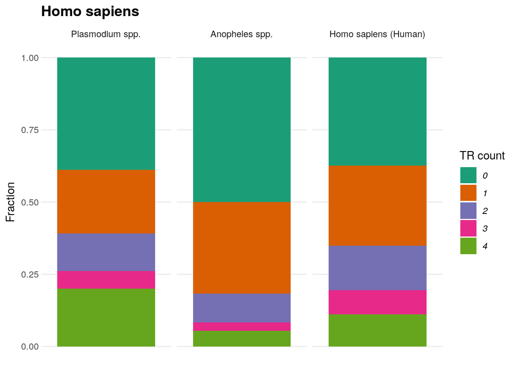

```r
# annotation data-frame
# ann_text <- data.frame(fraction_nTR = factor(as.character( c((df_parasite$fraction_nTR[1:5]), (df_parasite$fraction_nTR[6:10])))),
#                        lab = as.character( c((df_parasite$fraction_nTR[1:5]), (df_parasite$fraction_nTR[6:10]))),
#                        Superkingdom = df_parasite$Superkingdom)

#### Plots
if (DOBARPLOT_STACK){
  p <- ggplot(data=df_parasite, aes(x=factor(1), y=df_parasite$fraction_nTR, fill=df_parasite$nTR)) +
    geom_bar(stat="identity", position = "fill")+
    facet_grid(~organism)+
    # geom_text(aes(y = labpos, label=paste0(fraction_nTR*100,"%")), vjust=1.6,
    #           color="white", size=3.5)+
    # geom_label_repel(aes(label = nTR), size=4, show.legend = F, nudge_x = 1,
    #                  segment.size = .5, direction = 'x')+
    # geom_text(data = ann_text, label=paste0(as.numeric(as.character(ann_text$fraction_nTR))*100,"%"))+
    scale_fill_brewer(palette="Dark2")+
    ggtitle("Homo sapiens")+
    labs(x="", y="Fraction", fill= "TR count")+
    theme_minimal()
  p <- beautifier(p)+
    theme(
      axis.title.x = element_blank(),
      panel.border = element_blank(),
      panel.grid.minor = element_blank(),
      panel.grid.major.x = element_blank(),
      axis.ticks = element_blank(),
      axis.text.x.bottom = element_blank(),
      plot.title=element_text(size=14, face="bold")
    )
  print(p)
  if (save == TRUE) {
    ggsave(paste0(pathImages, "parasite_parasitehosts_bar", figureFormat), width=12, height=8, dpi = 300)}
} else if (DOPIECHART) {
  p <- ggplot(data=df_parasite, aes(x=factor(1), y=fraction_nTR, fill=nTR)) + # TODO: fix labeling according to: https://stackoverflow.com/questions/24803460/r-ggplot2-add-labels-on-facet-pie-chart
    geom_bar(stat="identity", position = "fill")+
    coord_polar("y", start = 0, direction = -1) +
    facet_grid(~organism)+
    # geom_text(aes(y=fraction_nTR, label=nTR), vjust=1.6,
    #           color="white", size=3.5)+
    scale_fill_brewer(palette="Dark2")+
    # ggtitle("Homo sapiens")+
    labs(fill= "TR count")+
    theme_minimal()
  p <- beautifier(p)+
    theme(
      axis.title.x = element_blank(),
      axis.title.y = element_blank(),
      panel.border = element_blank(),
      panel.grid=element_blank(),
      axis.ticks = element_blank(),
      axis.text = element_blank(),
      strip.text = element_text(size=12, face="bold")
      # plot.title=element_text(size=14, face="bold")
    )+
    # geom_label_repel(aes(label = paste0(fraction_nTR*100,"%")), size=4, show.legend = F, nudge_x = 1,
    #                  segment.size = .5, direction = 'x')
    geom_text(aes(y=labpos, label=paste0(fraction_nTR*100,"%")), vjust=1.6,
              color="white", size=3.5)
  print(p)
  if (save == TRUE) {
    ggsave(paste0(pathImages, "parasite_parasitehosts_pie", figureFormat), width=12, height=8, dpi = 300)}
} else if (DOBARPLOT) {
  p <- ggplot(data=df_parasite, aes(x=df_parasite$nTR, y=df_parasite$fraction_nTR, fill=df_parasite$nTR)) +
    geom_bar(stat="identity")+
    facet_grid(~organism)+
    # geom_text(aes(y = labpos, label=paste0(fraction_nTR*100,"%")), vjust=1.6,
    #           color="white", size=3.5)+
    # geom_label_repel(aes(label = nTR), size=4, show.legend = F, nudge_x = 1,
    #                  segment.size = .5, direction = 'x')+
    # geom_text(data = ann_text, label=paste0(as.numeric(as.character(ann_text$fraction_nTR))*100,"%"))+
    scale_fill_brewer(palette="Dark2")+
    ggtitle("Parasite - Parasite-host")+
    # labs(y="Fraction", x= "TR count", fill = "TR count")+
    labs(y="Fraction", x= "TR count", fill = "TR count")+
    theme_minimal()
  p <- beautifier(p)+
    theme(
      axis.title.x = element_blank(),
      panel.border = element_blank(),
      panel.grid.minor = element_blank(),
      panel.grid.major.x = element_blank(),
      axis.ticks = element_blank(),
      axis.text.x.bottom = element_blank(),
      # axis.text.x.bottom = element_text(angle = 0),
      plot.title=element_text(size=14, face="bold")
    )
  print(p)
  if (save == TRUE) {
    ggsave(paste0(pathImages, "parasite_parasitehosts_bar2", figureFormat), width=12, height=8, dpi = 300)}
}
```

-> look for parasite-host database: http://www.ontobee.org/